# R Notebook: initial exploration for Gas Cost Estimator

## Data preparations

Read in the `programs.csv` as generated by `src/program_generator.py` with `--fullCSV` flag on:

```r
setwd("~/sources/imapp/gas-cost-estimator/src")
```

```
The working directory was changed to /home/user/sources/imapp/gas-cost-estimator/src inside a notebook chunk. The working directory will be reset when the chunk is finished running. Use the knitr root.dir option in the setup chunk to change the working directory for notebook chunks.
```

```r
programs_evm = read.csv("../../local/programs.csv")
programs_ewasm = read.csv("../../local/programs_ewasm.csv")
```

Unfortunately `JUMP` and `JUMPI` are currently broken in `geth` (they require a `JUMPDEST`). Because they work in `evmone` (it prepends `JUMPDEST`) forcefully, we should drop them from the analisys. **TODO** fix this somehow. Also `RETURNDATACOPY` program generation is broken in general (`return data out of bounds`). `nop` for Ewasm isn’t executed at all in `openethereum`, drop it:

```r
programs_evm = programs_evm[which(programs_evm$opcode_measured != "JUMP"), ]
programs_evm = programs_evm[which(programs_evm$opcode_measured != "JUMPI"), ]
programs_evm = programs_evm[which(programs_evm$opcode_measured != "RETURNDATACOPY"), ]
programs_ewasm = programs_ewasm[which(programs_ewasm$opcode_measured != "nop"), ]

# necessary to get rid of the factor levels which we just filtered out
programs_evm = droplevels(programs_evm)
programs_ewasm = droplevels(programs_ewasm)

programs = rbind(programs_evm, programs_ewasm)
head(programs)
```

|  | program_id | opcode_measured | measured_op_position | bytecode |
| --- | --- | --- | --- | --- |
| 1 | STOP_0 | STOP | 1 | 600000 |
| 2 | ADD_0 | ADD | 2 | 6020602001 |
| 3 | MUL_0 | MUL | 2 | 6020602002 |
| 4 | SUB_0 | SUB | 2 | 6020602003 |
| 5 | DIV_0 | DIV | 2 | 6020602004 |
| 6 | SDIV_0 | SDIV | 2 | 6020602005 |

Modify `programs.csv` to adjust for the fact, that `evmone` prepends a `JUMPDEST` instruction at the vary beginning of each bytecode: (**TODO** track and adjust for the programs instructions more elegantly)

```r
programs$measured_op_position_evmone = programs$measured_op_position + 1
head(programs)
```

|  | program_id | opcode_measured | measured_op_position | bytecode | measured_op_position_evmone |
| --- | --- | --- | --- | --- | --- |
| 1 | STOP_0 | STOP | 1 | 600000 | 2 |
| 2 | ADD_0 | ADD | 2 | 6020602001 | 3 |
| 3 | MUL_0 | MUL | 2 | 6020602002 | 3 |
| 4 | SUB_0 | SUB | 2 | 6020602003 | 3 |
| 5 | DIV_0 | DIV | 2 | 6020602004 | 3 |
| 6 | SDIV_0 | SDIV | 2 | 6020602005 | 3 |

Modify `programs_ewasm.csv` to adjust for the fact, that there are many instructions executed before ours.

```r
programs$measured_op_position_ewasm = programs$measured_op_position + 11
head(programs)
```

|  | program_id | opcode_measured | measured_op_position | bytecode | measured_op_position_evmone | measured_op_position_ewasm |
| --- | --- | --- | --- | --- | --- | --- |
| 1 | STOP_0 | STOP | 1 | 600000 | 2 | 12 |
| 2 | ADD_0 | ADD | 2 | 6020602001 | 3 | 13 |
| 3 | MUL_0 | MUL | 2 | 6020602002 | 3 | 13 |
| 4 | SUB_0 | SUB | 2 | 6020602003 | 3 | 13 |
| 5 | DIV_0 | DIV | 2 | 6020602004 | 3 | 13 |
| 6 | SDIV_0 | SDIV | 2 | 6020602005 | 3 | 13 |

Read in the `result_geth.csv` and `result_evmone.csv` as generated by `src/measurements.py`

```r
setwd("~/sources/imapp/gas-cost-estimator/src")
```

```
The working directory was changed to /home/user/sources/imapp/gas-cost-estimator/src inside a notebook chunk. The working directory will be reset when the chunk is finished running. Use the knitr root.dir option in the setup chunk to change the working directory for notebook chunks.
```

```r
result_geth = read.csv("../../local/result_geth.csv")
result_evmone = read.csv("../../local/result_evmone.csv")
result_openethereum = read.csv("../../local/result_openethereum.csv")
result_ewasm = read.csv("../../local/result_ewasm.csv")
result_geth$env = "geth"
result_evmone$env = "evmone"
result_openethereum$env = "openethereum"
result_ewasm$env = "ewasm"
results = rbind(result_geth, result_evmone, result_openethereum, result_ewasm)
head(results)
```

|  | program_id | sample_id | run_id | instruction_id | measure_all_time_ns | measure_one_time_ns | env |
| --- | --- | --- | --- | --- | --- | --- | --- |
| 1 | STOP_0 | 0 | 0 | 0 | 6622 | NA | geth |
| 2 | STOP_0 | 0 | 0 | 1 | 114 | NA | geth |
| 3 | STOP_0 | 0 | 1 | 0 | 2697 | NA | geth |
| 4 | STOP_0 | 0 | 1 | 1 | 106 | NA | geth |
| 5 | STOP_0 | 0 | 2 | 0 | 3156 | NA | geth |
| 6 | STOP_0 | 0 | 2 | 1 | 108 | NA | geth |

Combine the two tables to see only times of the measured opcodes.

```r
measurements = sqldf("SELECT opcode_measured, sample_id, run_id, measure_all_time_ns, env
                     FROM results
                     INNER JOIN
                       programs ON(results.program_id = programs.program_id)
                     WHERE
                       (results.instruction_id = programs.measured_op_position AND results.env = 'geth') OR
                       (results.instruction_id = programs.measured_op_position_evmone AND results.env = 'evmone') OR
                       (results.instruction_id = programs.measured_op_position AND results.env = 'openethereum') OR
                       (results.instruction_id = programs.measured_op_position_ewasm AND results.env = 'ewasm')
                     ")

head(measurements)
```

|  | opcode_measured | sample_id | run_id | measure_all_time_ns | env |
| --- | --- | --- | --- | --- | --- |
| 1 | STOP | 0 | 0 | 114 | geth |
| 2 | STOP | 0 | 1 | 106 | geth |
| 3 | STOP | 0 | 2 | 108 | geth |
| 4 | STOP | 0 | 3 | 109 | geth |
| 5 | STOP | 0 | 4 | 119 | geth |
| 6 | STOP | 0 | 5 | 105 | geth |

**TODO** some result CSVs don’t look good, some measurements are missing, investigate (mainly impacts the excluded OPCODEs):

Let’s also adjust for the rough estimate of the overhead of the timer. We’re subtracting these estimates from all measurements, for more granularity on the fastest instructions.

Our “ball-park” estimates of minimum clock measurement overhead:

- blue - `geth` - `17ns` ([minimum for `runtimeNano`](https://htmlpreview.github.io/?https://github.com/imapp-pl/gas-cost-estimator/blob/master/src/analysis/exploration_timers.nb.html))
  - (earlier try: `30ns` median for `runtimeNano` from a different measurement)
- pink - `evmone` - `16ns` (minimum, see link as above)
  - (earlier try: `9ns` wild guess, half of smallest measurement)
  - (2nd earlier try: `29.32ns` as below with earlier set of result data)
  - (3rd earlier try: `28.32ns` (2nd wild guess, this makes our results calibrate with ones inferred from [`chfast`’s benchmarks](https://notes.ethereum.org/@chfast/benchmarking-evm-instructions). We try here to have `NOT` opcode match the time from there, which is `881us/256/2048 = 1.68ns`. Our median measurement without adjustment was `30`, so `30 - 1.68 = 28.32ns`)
- green - `openethereum` - `17ns` (minimum, see link as above)
  - (earlier try: `30ns` just the same as `geth` above)
- yellow - `ewasm` - same as `openethereum`

```r
rough_estimate_time_overhead_geth = 17
rough_estimate_time_overhead_evmone = 16
rough_estimate_time_overhead_openethereum = 17

measurements_geth = measurements[which(measurements$env=="geth"), ]
measurements_evmone = measurements[which(measurements$env=="evmone"), ]
measurements_openethereum = measurements[which(measurements$env=="openethereum"), ]
measurements_ewasm = measurements[which(measurements$env=="ewasm"), ]

measurements_geth$measure_all_time_ns_raw = measurements_geth$measure_all_time_ns
measurements_evmone$measure_all_time_ns_raw = measurements_evmone$measure_all_time_ns
measurements_openethereum$measure_all_time_ns_raw = measurements_openethereum$measure_all_time_ns
measurements_ewasm$measure_all_time_ns_raw = measurements_ewasm$measure_all_time_ns

measurements_geth$measure_all_time_ns = measurements_geth$measure_all_time_ns_raw - rough_estimate_time_overhead_geth
measurements_evmone$measure_all_time_ns = measurements_evmone$measure_all_time_ns_raw - rough_estimate_time_overhead_evmone
measurements_openethereum$measure_all_time_ns = measurements_openethereum$measure_all_time_ns_raw - rough_estimate_time_overhead_openethereum
measurements_ewasm$measure_all_time_ns = measurements_ewasm$measure_all_time_ns_raw - rough_estimate_time_overhead_openethereum
measurements = rbind(measurements_geth, measurements_evmone, measurements_openethereum, measurements_ewasm)

check_columns = c("env", "measure_all_time_ns", "measure_all_time_ns_raw")
head(measurements)
```

|  | opcode_measured | sample_id | run_id | measure_all_time_ns | env | measure_all_time_ns_raw |
| --- | --- | --- | --- | --- | --- | --- |
| 1 | STOP | 0 | 0 | 97 | geth | 114 |
| 2 | STOP | 0 | 1 | 89 | geth | 106 |
| 3 | STOP | 0 | 2 | 91 | geth | 108 |
| 4 | STOP | 0 | 3 | 92 | geth | 109 |
| 5 | STOP | 0 | 4 | 102 | geth | 119 |
| 6 | STOP | 0 | 5 | 88 | geth | 105 |

A necessary touch to prepare the data - we want the opcodes factor to be ordered by the natural opcode order. For now we’ll use the original order from `programs.csv`, which coincides, but this must be improved (**TODO**). We’ll also have `geth` first, and proceed in the order of completing the instrumentations.

```r
measurements$env = factor(measurements$env, levels=c("geth", "evmone", "openethereum", "ewasm"))
measurements$env_evm = factor(measurements$env, levels=c("geth", "evmone", "openethereum"))

measurements$opcode_measured_evm = factor(measurements$opcode_measured, levels=programs_evm$opcode_measured)
measurements$opcode_measured_ewasm = factor(measurements$opcode_measured, levels=programs_ewasm$opcode_measured)
measurements$opcode_measured = factor(measurements$opcode_measured, levels=programs$opcode_measured)
```

## Overview

Quick overview of times; everything and by env:

```r
summary(measurements$measure_all_time_ns)
```

```
    Min.  1st Qu.   Median     Mean  3rd Qu.     Max.
    3.00    24.00    49.00    83.51    75.00 22328.00
```

```r
tapply(measurements$measure_all_time_ns, measurements$env, summary)
```

```
$geth
   Min. 1st Qu.  Median    Mean 3rd Qu.    Max.
   27.0    48.0   100.0   112.5   117.0 15500.0

$evmone
    Min.  1st Qu.   Median     Mean  3rd Qu.     Max.
    3.00    12.00    13.00    24.68    21.00 20567.00

$openethereum
   Min. 1st Qu.  Median    Mean 3rd Qu.    Max.
   18.0    50.0    65.0   126.3    73.0 22328.0

$ewasm
   Min. 1st Qu.  Median    Mean 3rd Qu.    Max.
  19.00   34.00   40.00   41.37   45.00  481.00
```

Quick overview of measurements per opcode:

```r
measurements_geth = measurements[which(measurements$env=="geth"), ]
measurements_evmone = measurements[which(measurements$env=="evmone"), ]
measurements_openethereum = measurements[which(measurements$env=="openethereum"), ]
measurements_ewasm = measurements[which(measurements$env=="ewasm"), ]

print("geth")
```

```
[1] "geth"
```

```r
tapply(measurements_geth$measure_all_time_ns, measurements_geth$opcode_measured_evm, summary)
```

```
$STOP
   Min. 1st Qu.  Median    Mean 3rd Qu.    Max.
   79.0   102.0   109.0   109.5   115.2   173.0

$ADD
   Min. 1st Qu.  Median    Mean 3rd Qu.    Max.
  30.00   34.00   36.00   39.41   45.25   81.00

$MUL
   Min. 1st Qu.  Median    Mean 3rd Qu.    Max.
  30.00   36.00   39.00   42.88   50.00   66.00

$SUB
   Min. 1st Qu.  Median    Mean 3rd Qu.    Max.
  29.00   36.00   41.50   43.42   50.00   80.00

$DIV
   Min. 1st Qu.  Median    Mean 3rd Qu.    Max.
  32.00   40.00   47.00   48.91   56.25   79.00

$SDIV
   Min. 1st Qu.  Median    Mean 3rd Qu.    Max.
  31.00   36.00   39.00   42.10   47.25   62.00

$MOD
   Min. 1st Qu.  Median    Mean 3rd Qu.    Max.
  32.00   36.00   39.00   42.78   50.00   61.00

$SMOD
   Min. 1st Qu.  Median    Mean 3rd Qu.    Max.
  33.00   37.00   42.00   44.35   51.00   73.00

$ADDMOD
   Min. 1st Qu.  Median    Mean 3rd Qu.    Max.
  32.00   35.75   42.00   44.17   53.00   70.00

$MULMOD
   Min. 1st Qu.  Median    Mean 3rd Qu.    Max.
  30.00   35.00   43.00   44.56   53.00   69.00

```

[output cut: 400 more lines]

```
$SWAP16
   Min. 1st Qu.  Median    Mean 3rd Qu.    Max.
   34.0   242.0   271.5   317.8   291.0  8465.0

$RETURN
   Min. 1st Qu.  Median    Mean 3rd Qu.    Max.
  350.0   443.0   470.0   469.4   501.0   636.0

$REVERT
   Min. 1st Qu.  Median    Mean 3rd Qu.    Max.
  338.0   449.8   473.5   476.3   495.2  1251.0

$INVALID
   Min. 1st Qu.  Median    Mean 3rd Qu.    Max.
  260.0   318.0   339.0   340.1   358.0   479.0
```

```r
print("evmone")
```

```
[1] "evmone"
```

```r
tapply(measurements_evmone$measure_all_time_ns, measurements_evmone$opcode_measured_evm, summary)
```

```
$STOP
   Min. 1st Qu.  Median    Mean 3rd Qu.    Max.
    8.0     9.0    10.0   101.9    11.0 18206.0

$ADD
   Min. 1st Qu.  Median    Mean 3rd Qu.    Max.
   9.00   12.00   13.00   16.07   14.00  458.00

$MUL
   Min. 1st Qu.  Median    Mean 3rd Qu.    Max.
  18.00   19.00   20.00   20.96   20.00  113.00

$SUB
   Min. 1st Qu.  Median    Mean 3rd Qu.    Max.
  12.00   14.00   15.00   16.04   16.00  103.00

$DIV
   Min. 1st Qu.  Median    Mean 3rd Qu.    Max.
   45.0    48.0    48.0    60.7    49.0  1813.0

$SDIV
   Min. 1st Qu.  Median    Mean 3rd Qu.    Max.
  50.00   51.00   51.00   61.66   52.00 1294.00

$MOD
   Min. 1st Qu.  Median    Mean 3rd Qu.    Max.
  50.00   51.00   52.00   56.91   54.00  260.00

$SMOD
   Min. 1st Qu.  Median    Mean 3rd Qu.    Max.
  47.00   49.00   50.00   74.97   51.00 1753.00

$ADDMOD
   Min. 1st Qu.  Median    Mean 3rd Qu.    Max.
  58.00   61.00   62.00   93.09   63.00 2603.00

$MULMOD
   Min. 1st Qu.  Median    Mean 3rd Qu.    Max.
   71.0    74.0    76.0   162.8    77.0 14155.0

```

[output cut: 400 more lines]

```
$SWAP16
   Min. 1st Qu.  Median    Mean 3rd Qu.    Max.
   9.00   12.00   14.00   14.12   14.00   48.00

$RETURN
   Min. 1st Qu.  Median    Mean 3rd Qu.    Max.
  23.00   25.00   26.00   36.38   27.00  561.00

$REVERT
   Min. 1st Qu.  Median    Mean 3rd Qu.    Max.
   23.0    27.0    27.5    47.2    41.0  1829.0

$INVALID
   Min. 1st Qu.  Median    Mean 3rd Qu.    Max.
   9.00   10.00   11.00   10.91   11.00   21.00
```

```r
print("openethereum")
```

```
[1] "openethereum"
```

```r
tapply(measurements_openethereum$measure_all_time_ns, measurements_openethereum$opcode_measured_evm, summary)
```

```
$STOP
   Min. 1st Qu.  Median    Mean 3rd Qu.    Max.
  40.00   42.00   44.00   54.91   45.00  559.00

$ADD
    Min.  1st Qu.   Median     Mean  3rd Qu.     Max.
   66.00    70.00    72.00   174.13    78.25 18691.00

$MUL
    Min.  1st Qu.   Median     Mean  3rd Qu.     Max.
   67.00    73.00    80.00   178.71    82.25 18905.00

$SUB
   Min. 1st Qu.  Median    Mean 3rd Qu.    Max.
   68.0    71.0    79.0   178.8    81.0 18894.0

$DIV
   Min. 1st Qu.  Median    Mean 3rd Qu.    Max.
   75.0    79.0    84.0   281.3    88.0 18962.0

$SDIV
   Min. 1st Qu.  Median    Mean 3rd Qu.    Max.
  114.0   119.0   133.0   335.1   145.0 19327.0

$MOD
   Min. 1st Qu.  Median    Mean 3rd Qu.    Max.
  116.0   120.0   129.0   421.3   136.0 19437.0

$SMOD
   Min. 1st Qu.  Median    Mean 3rd Qu.    Max.
  131.0   144.0   148.0   357.7   154.2 19686.0

$ADDMOD
   Min. 1st Qu.  Median    Mean 3rd Qu.    Max.
  288.0   294.0   300.0   343.5   303.0  4133.0

$MULMOD
   Min. 1st Qu.  Median    Mean 3rd Qu.    Max.
  313.0   387.8   403.0   831.7   419.0 22328.0

```

[output cut: 400 more lines]

```
$SWAP16
   Min. 1st Qu.  Median    Mean 3rd Qu.    Max.
  61.00   66.00   68.00   73.55   69.00  317.00

$RETURN
   Min. 1st Qu.  Median    Mean 3rd Qu.    Max.
  111.0   122.0   130.0   531.5   137.0 19544.0

$REVERT
   Min. 1st Qu.  Median    Mean 3rd Qu.    Max.
  36.00   39.00   40.00   44.49   41.00  255.00

$INVALID
   Min. 1st Qu.  Median    Mean 3rd Qu.    Max.
  18.00   22.00   22.00   25.71   24.00  165.00
```

```r
print("ewasm")
```

```
[1] "ewasm"
```

```r
tapply(measurements_ewasm$measure_all_time_ns, measurements_ewasm$opcode_measured_ewasm, summary)
```

```
$drop
   Min. 1st Qu.  Median    Mean 3rd Qu.    Max.
  28.00   31.00   32.00   33.02   34.00   53.00

$select
   Min. 1st Qu.  Median    Mean 3rd Qu.    Max.
  31.00   34.00   36.00   38.09   41.00   62.00

$`local.get $x`
   Min. 1st Qu.  Median    Mean 3rd Qu.    Max.
  39.00   43.00   45.00   45.65   46.00  128.00

$`local.set $x`
   Min. 1st Qu.  Median    Mean 3rd Qu.    Max.
  33.00   41.00   43.00   43.89   48.00   55.00

$`local.tee $x`
   Min. 1st Qu.  Median    Mean 3rd Qu.    Max.
  32.00   39.00   40.00   42.47   43.00  129.00

$`i32.const 32`
   Min. 1st Qu.  Median    Mean 3rd Qu.    Max.
  19.00   22.00   24.00   24.73   27.00   34.00

$i32.eqz
   Min. 1st Qu.  Median    Mean 3rd Qu.    Max.
  22.00   32.00   33.00   32.92   34.00   51.00

$i32.eq
   Min. 1st Qu.  Median    Mean 3rd Qu.    Max.
   33.0    38.0    40.0    41.9    44.0   118.0

$i32.ne
   Min. 1st Qu.  Median    Mean 3rd Qu.    Max.
  35.00   40.00   42.50   43.75   45.00  122.00

$i32.lt_s
   Min. 1st Qu.  Median    Mean 3rd Qu.    Max.
  25.00   36.00   39.00   39.33   41.00   53.00

```

[output cut: 84 more lines]

```
$i32.shr_s
   Min. 1st Qu.  Median    Mean 3rd Qu.    Max.
   40.0    44.0    45.0    51.6    58.0   129.0

$i32.shr_u
   Min. 1st Qu.  Median    Mean 3rd Qu.    Max.
   41.0    44.0    46.0    48.6    49.0   142.0

$i32.rotl
   Min. 1st Qu.  Median    Mean 3rd Qu.    Max.
  41.00   44.00   46.00   48.74   49.00  261.00

$i32.rotr
   Min. 1st Qu.  Median    Mean 3rd Qu.    Max.
  40.00   43.00   44.00   47.53   49.00  165.00
```

`PUSH1`-`PUSH8` OPCODEs for `evmone` are extremely cheap, they’re additionally optimized there.

(Pushes of more than 8 bytes look more expensive, what is special about pushes under 8 bytes for `evmone`?

Mystery solved in `evmone/lib/evmone/opcodes_helpers.h`:

```c
#define ANY_SMALL_PUSH \
    OP_PUSH1:          \
    case OP_PUSH2:     \
    case OP_PUSH3:     \
    case OP_PUSH4:     \
    case OP_PUSH5:     \
    case OP_PUSH6:     \
    case OP_PUSH7:     \
    case OP_PUSH8
```

- they get special treatment)

## Implementation-relative measurements

We want to introduce a notion of implementation-relative measurements, where we express them in the multiples of “mean `COINBASE` duration”, as opposed to ns. Let’s call the selected operation **“pivot OPCODE”**.

We’re using `COINBASE` as the pivot OPCODE because it is (**TODO** verify all points, pick a better one):

- relatively slow, so timer measurement overhead and precision have little impact
- seems to be free of surprises or influences of suboptimal implementation
- no outliers
- seem to be a rather typical opcode in terms of timing in both implementations (it allows similar calibration to that using an overall mean)
- `COINBASE` seems a rather peculiar choice for a pivot OPCODE, but `¯\_(ツ)_/¯`
- (earlier pick was `POP`, but it is very cheap, close to timer measurement and precision)
- (second pick was `EXP(0, 0)`, but it had a bad outlier, we can revisit after the `evmone` outliers are sorted, **TODO**)
- (third and fourth picks were `MULMOD(0, 0, 0)` and `GT(0, 0)`, but they belong to two groups which time very differently in `geth`/`evmone` - `geth` seems faster in arithmetic and slower in logical and comparison operators (**TODO** explore this more)

For Ewasm we’re using `i32.const 32` which seems to give the most reliable result.

```r
measurements_geth = measurements[which(measurements$env=="geth"), ]
measurements_evmone = measurements[which(measurements$env=="evmone"), ]
measurements_openethereum = measurements[which(measurements$env=="openethereum"), ]
measurements_ewasm = measurements[which(measurements$env=="ewasm"), ]

pivot_opcode = "COINBASE"
pivot_opcode_ewasm = "i32.const 32"
means = c(
  mean(measurements_geth[which(measurements_geth$opcode_measured==pivot_opcode), "measure_all_time_ns"]),
  mean(measurements_evmone[which(measurements_geth$opcode_measured==pivot_opcode), "measure_all_time_ns"]),
  mean(measurements_openethereum[which(measurements_openethereum$opcode_measured==pivot_opcode), "measure_all_time_ns"]),
  mean(measurements_ewasm[which(measurements_ewasm$opcode_measured==pivot_opcode_ewasm), "measure_all_time_ns"])
)

pivot_statistics = data.frame(
  mean_measure_all_time_ns=means, row.names=c("geth", "evmone", "openethereum", "ewasm")
)
head(pivot_statistics)
```

|  | mean_measure_all_time_ns |
| --- | --- |
| geth | 113.310 |
| evmone | 40.900 |
| openethereum | 73.875 |
| ewasm | 24.735 |

```r
measurements_geth$measure_all_time_ns_rel = measurements_geth$measure_all_time_ns / pivot_statistics["geth", "mean_measure_all_time_ns"]
measurements_evmone$measure_all_time_ns_rel = measurements_evmone$measure_all_time_ns / pivot_statistics["evmone", "mean_measure_all_time_ns"]
measurements_openethereum$measure_all_time_ns_rel = measurements_openethereum$measure_all_time_ns / pivot_statistics["openethereum", "mean_measure_all_time_ns"]
measurements_ewasm$measure_all_time_ns_rel = measurements_ewasm$measure_all_time_ns / pivot_statistics["ewasm", "mean_measure_all_time_ns"]
measurements = rbind(measurements_geth, measurements_evmone, measurements_openethereum, measurements_ewasm)

check_columns = c("env", "measure_all_time_ns", "measure_all_time_ns_rel")
head(measurements[which(measurements$opcode_measured==pivot_opcode & measurements$env=="geth"), check_columns])
```

|  | env | measure_all_time_ns | measure_all_time_ns_rel |
| --- | --- | --- | --- |
| 6801 | geth | 115 | 1.0149148 |
| 6802 | geth | 114 | 1.0060895 |
| 6803 | geth | 109 | 0.9619628 |
| 6804 | geth | 101 | 0.8913600 |
| 6805 | geth | 119 | 1.0502162 |
| 6806 | geth | 168 | 1.4826582 |

```r
head(measurements[which(measurements$opcode_measured==pivot_opcode & measurements$env=="evmone"), check_columns])
```

|  | env | measure_all_time_ns | measure_all_time_ns_rel |
| --- | --- | --- | --- |
| 29601 | evmone | 156 | 3.8141809 |
| 29602 | evmone | 53 | 1.2958435 |
| 29603 | evmone | 44 | 1.0757946 |
| 29604 | evmone | 37 | 0.9046455 |
| 29605 | evmone | 36 | 0.8801956 |
| 29606 | evmone | 36 | 0.8801956 |

```r
head(measurements[which(measurements$opcode_measured==pivot_opcode & measurements$env=="openethereum"), check_columns])
```

|  | env | measure_all_time_ns | measure_all_time_ns_rel |
| --- | --- | --- | --- |
| 52393 | openethereum | 612 | 8.2842640 |
| 52394 | openethereum | 128 | 1.7326565 |
| 52395 | openethereum | 72 | 0.9746193 |
| 52396 | openethereum | 73 | 0.9881557 |
| 52397 | openethereum | 73 | 0.9881557 |
| 52398 | openethereum | 80 | 1.0829103 |

```r
head(measurements[which(measurements$opcode_measured==pivot_opcode_ewasm & measurements$env=="ewasm"), check_columns])
```

|  | env | measure_all_time_ns | measure_all_time_ns_rel |
| --- | --- | --- | --- |
| 69385 | ewasm | 25 | 1.0107136 |
| 69386 | ewasm | 25 | 1.0107136 |
| 69387 | ewasm | 23 | 0.9298565 |
| 69388 | ewasm | 25 | 1.0107136 |
| 69389 | ewasm | 25 | 1.0107136 |
| 69390 | ewasm | 29 | 1.1724277 |

## Measurements exploration

Let’s compare the implementations in an absolute fashion (note we’re not showing outliers for `evmone` because they’re very large - **TODO** investigate what happened. UPDATE: `geth` has massive outliers too, after adding all the opcodes):

```r
par(mfrow=c(3,1), mar = c(6,4,1,2) + 0.1)
boxplot(measure_all_time_ns ~ opcode_measured_evm, data=measurements_geth, col=geth_color, outline=FALSE, las=2)
boxplot(measure_all_time_ns ~ opcode_measured_evm, data=measurements_evmone, col=evmone_color, las=2, outline=FALSE, xaxt="n")
```

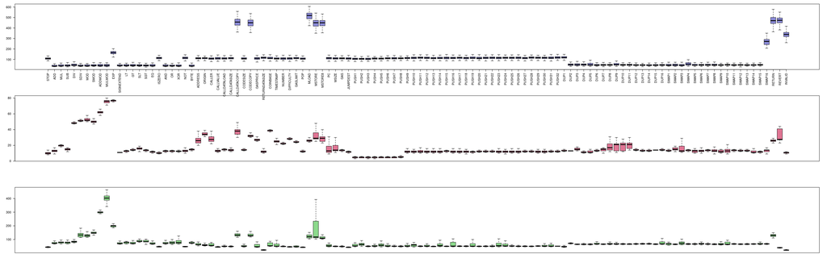

```r
boxplot(measure_all_time_ns ~ opcode_measured_evm, data=measurements_openethereum, col=openethereum_color, las=2, outline=FALSE, xaxt="n")
```

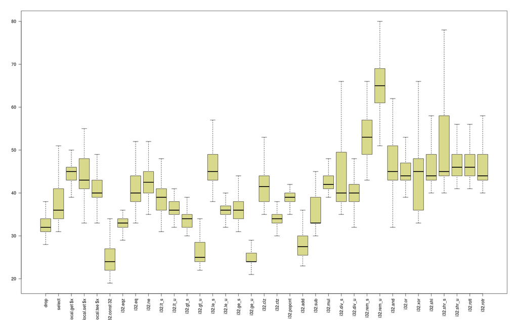

```r
measurements_ewasm = measurements[which(measurements$env=="ewasm"), ]

boxplot(measure_all_time_ns ~ opcode_measured_ewasm, data=measurements_ewasm, col=ewasm_color, outline=FALSE, las=2)
```

To compare the opcodes on a single boxplot side by side, still absolute times:

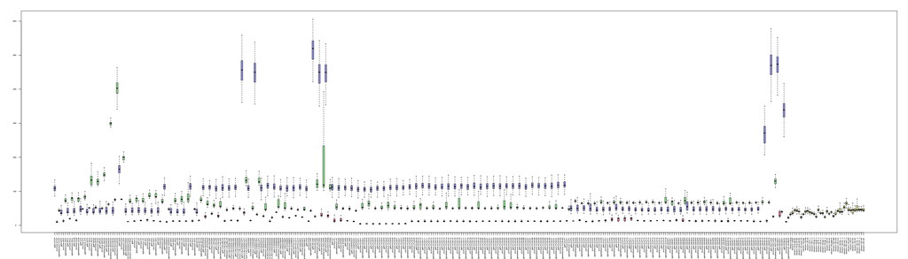

```r
# col is recycled so we need to match exactly the sequence we want here - first evm, then ewasm
# drop makes empty boxplots not show up, i.e. `PUSH1` for `ewasm`
boxplot(measure_all_time_ns ~ env:opcode_measured, data=measurements, las=2, col=mix_colors, outline=FALSE, cex.axis=0.5, drop=TRUE)
```

Now let’s compare using the relative times, measured in multiples of the duration of the pivot OPCODE (see above):

```r
par(mar = c(8,4,1,2) + 0.1)
boxplot(measure_all_time_ns_rel ~ env:opcode_measured, data=measurements, las=2, col=mix_colors, outline=FALSE, cex.axis=0.5, drop=TRUE)
legend(-10, 6.3, c("Geth", "Evmone", "OpenEthereum", "OpenEthereum Ewasm"), fill=env_colors, cex=1.3)
```

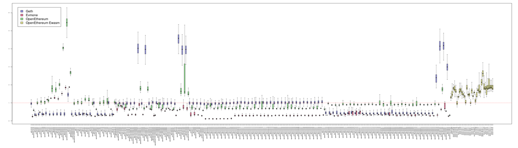

```r
abline(h=1, col="red", lty=3)
```

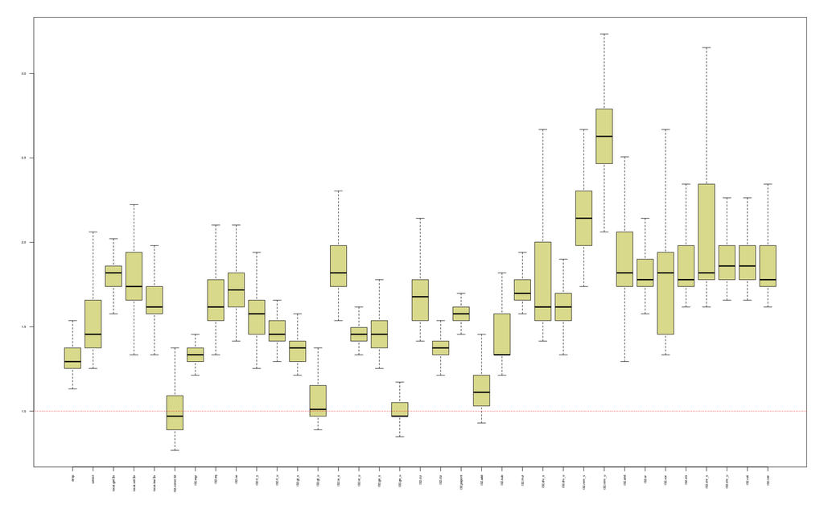

```r
measurements_ewasm = measurements[which(measurements$env=="ewasm"), ]

boxplot(measure_all_time_ns_rel ~ opcode_measured_ewasm, data=measurements_ewasm, las=2, col=ewasm_color, outline=FALSE, cex.axis=0.5)
abline(h=1, col="red", lty=3)
```

The red, dotted line is 1, which coincides with respective mean of pivot OPCODE (see above) measurement for the different environments.

**TODO** check these again, some look weird.

```r
measurements_geth = measurements[which(measurements$env=="geth"), ]
measurements_evmone = measurements[which(measurements$env=="evmone"), ]
measurements_openethereum = measurements[which(measurements$env=="openethereum"), ]
measurements_ewasm = measurements[which(measurements$env=="ewasm"), ]

n_programs = nrow(programs)
n_plot_cols = 17
n_plot_rows = n_programs %/% n_plot_cols + 1
```

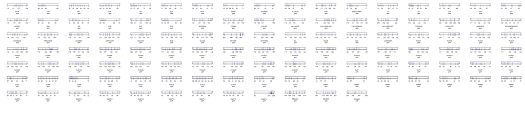

```r
par(mfrow=c(n_plot_rows, n_plot_cols))
for (opcode in programs_evm$opcode_measured)
{
  frequencies = sort(table(measurements_geth[which(measurements_geth$opcode_measured_evm==opcode), "measure_all_time_ns_raw"]), decreasing=TRUE)
  n = min(10, nrow(frequencies))
  plot(frequencies[1:n], yaxt="n", ylab="", xlab=c(opcode, " geth"), col=geth_color)
}
```

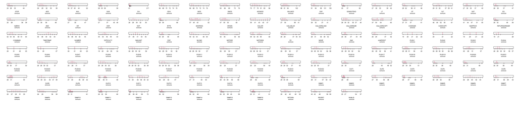

```r
par(mfrow=c(n_plot_rows, n_plot_cols))
for (opcode in programs_evm$opcode_measured)
{
  frequencies = sort(table(measurements_evmone[which(measurements_evmone$opcode_measured_evm==opcode), "measure_all_time_ns_raw"]), decreasing=TRUE)
  n = min(10, nrow(frequencies))
  if (length(frequencies) == 0) next
  plot(frequencies[1:n], yaxt="n", ylab="", xlab=c(opcode, " evmone"), col=evmone_color)
}
```

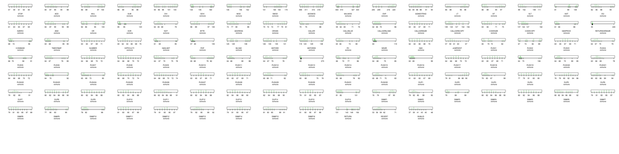

```r
par(mfrow=c(n_plot_rows, n_plot_cols))
for (opcode in programs_evm$opcode_measured)
{
  frequencies = sort(table(measurements_openethereum[which(measurements_openethereum$opcode_measured_evm==opcode), "measure_all_time_ns_raw"]), decreasing=TRUE)
  n = min(10, nrow(frequencies))
  if (length(frequencies) == 0) next
  plot(frequencies[1:n], yaxt="n", ylab="", xlab=c(opcode, " evmone"), col=openethereum_color)
}
```

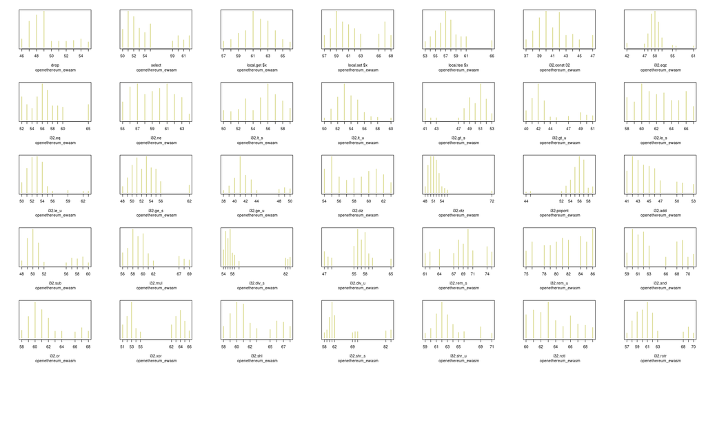

```r
n_programs = nrow(programs_ewasm)
n_plot_cols = 7
n_plot_rows = n_programs %/% n_plot_cols + 1
par(mfrow=c(n_plot_rows, n_plot_cols))
for (opcode in programs_ewasm$opcode_measured)
{
  frequencies = sort(table(measurements_ewasm[which(measurements_ewasm$opcode_measured_ewasm==opcode), "measure_all_time_ns_raw"]), decreasing=TRUE)
  n = min(10, nrow(frequencies))
  if (length(frequencies) == 0) next
  plot(frequencies[1:n], yaxt="n", ylab="", xlab=c(opcode, " openethereum_ewasm"), col=ewasm_color)
}
```

## Exploration of other warm-up

Quick check that `sample_id` shouldn’t impact measurements:

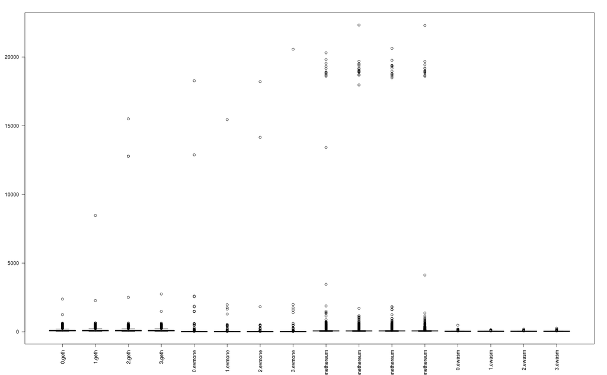

```r
boxplot(measure_all_time_ns ~ sample_id:env, data=measurements, las=2)
```

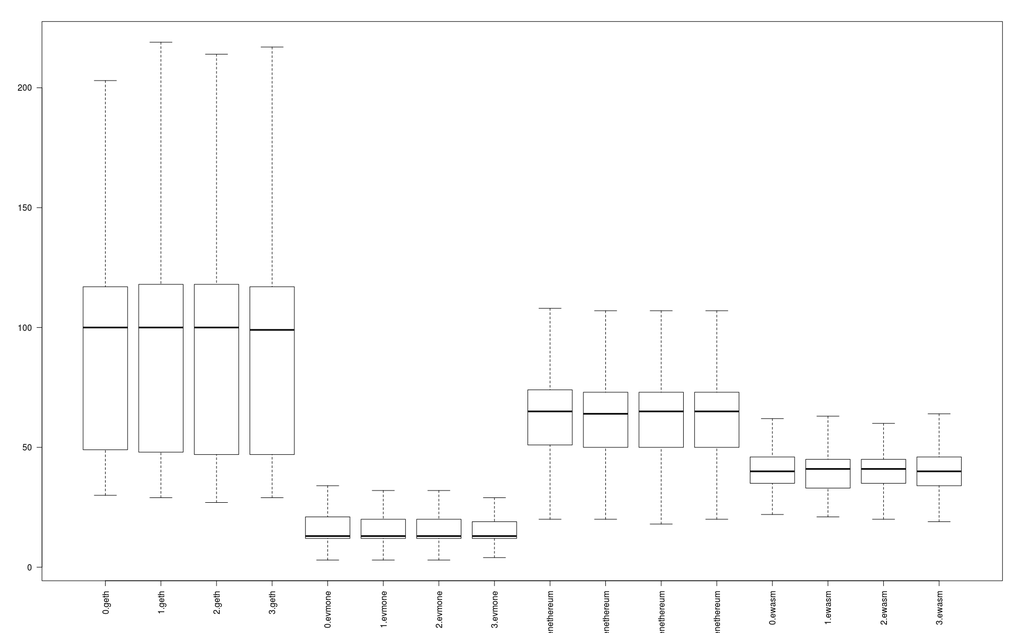

```r
boxplot(measure_all_time_ns ~ sample_id:env, data=measurements, outline=FALSE, las=2)
```

But `run_id` does impact measurements: first several runs have a decreasing trend. **TODO** needs investigation how/if to alleviate (**TODO** we probably should undo the warm-up for `geth`, others don’t do this and it shows here. If at all, discard warm-up on analysis stage):

```r
measurements_geth = measurements[which(measurements$env=="geth"), ]
measurements_evmone = measurements[which(measurements$env=="evmone"), ]
measurements_openethereum = measurements[which(measurements$env=="openethereum"), ]
measurements_ewasm = measurements[which(measurements$env=="ewasm"), ]

par(mfrow=c(2,2))
boxplot(measure_all_time_ns ~ run_id, data=measurements_geth, las=2, outline=FALSE, xlab="geth")
boxplot(measure_all_time_ns ~ run_id, data=measurements_evmone, las=2, outline=FALSE, xlab="evmone")
```

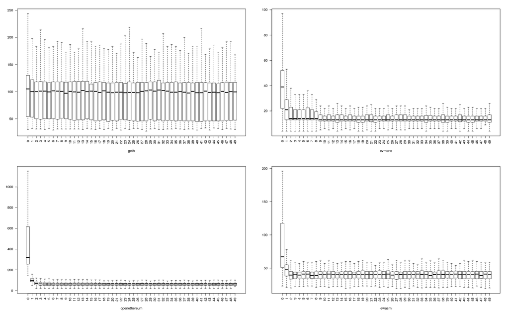

```r
boxplot(measure_all_time_ns ~ run_id, data=measurements_openethereum, las=2, outline=FALSE, xlab="openethereum")
boxplot(measure_all_time_ns ~ run_id, data=measurements_ewasm, las=2, outline=FALSE, xlab="ewasm")
```